# COVID-19 Vaccination Data Analysis

## CMSC320 Final Tutorial

### *By: Alexander Ramirez, Jonathan Hayden, Christopher Tang*

## Table of Contents:

1. Introduction
2. Necessary Imports
3. Information About The Data
4. Data Collection: Scraping
5. Data Processing: Cleaning
6. Exploratory Data Analysis
7. Hypothesis Testing
8. Future Work
9. References

## 1. Introduction

The Covid-19 pandemic has thrust many people into quarantines. After months of the pandemic, multiple vaccines have been developed to combat the virus. This tutorial will walk through an analysis of data presented by Johns Hopkins University. While observations of increasing vaccinations are easier to do, understanding trends of the data and comparing states to one another requires more data analysis. As such it is our goal to help explain the Johns Hopking Vaccination dataset as well as our methods utilized in our analysis.

## 2. Necessary Imports

In order to follow along with the tutorial, it is required that you have at least Python 3. It is recommended that you have Python 3.9, as that is one of the more recent releases of Python that will function for this tutorial.

The following Python libraries are also required:

- NumPy
- Pandas
- Matplotlib
- BeautifulSoup
- Requests
- SymPy
- Datetime
- Urllib
- SciPy

Make sure you have everything downloaded before moving on!

```python
%matplotlib inline
from sympy import S, symbols, printing
import numpy as np
import pandas as pd
import matplotlib.pyplot as plt
import requests
from datetime import datetime
from datetime import date
from bs4 import BeautifulSoup
import urllib.request
from urllib.request import urlopen
from scipy.stats import ttest_1samp, ttest_ind

pd.options.mode.chained_assignment=None  # suppress warnings
```

## 3. Information About the Data

When conducting a thorough data analysis, the first thing that we want to do is find and obtain a dataset for us to manipulate. We ended up choosing [Johns Hopkins Vaccination Data](https://github.com/govex/COVID-19/blob/master/data_tables/vaccine_data/us_data/time_series/people_vaccinated_us_timeline.csv). This dataset contains information regarding vaccination data across each of the 50 U.S. states, as well as D.C., Puerto Rico, and various other U.S. territories.

As stated on the Johns Hopkins GitHub page: “This website and its contents herein, including all data, mapping, and analysis (“Website”), copyright 2020 Johns Hopkins University, all rights reserved, is provided to the public strictly for public health, educational, and academic research purposes. Redistribution of the Website or the aggregated data set underlying the Website is strictly prohibited. You are welcome to link to the Website, however.”

Thankfully for us, we intend to utilize this data for educational purposes, which means that we are able to access it freely. We appreciate Johns Hopkins for allowing us to work with this particular dataset, as we believe that analysis of the set will lead us to better understand issues regarding vaccination rates, the proportions of individuals vaccinated between states, etc.

## 4. Data Collection: Scraping

The [data](https://github.com/govex/COVID-19/blob/master/data_tables/vaccine_data/us_data/time_series/people_vaccinated_us_timeline.csv) is stored as a .csv file on the [Centers for Civic Impact](https://github.com/govex) GitHub page, under the "COVID-19" repository.

In order to obtain the data and manipulate it, we decided to store it into a Pandas DataFrame. To do this, we got the url to the raw .csv page for the vaccination data, and read the data itself into a variable using the Pandas read_csv() function. Since the data itself was already stored into a .csv file, most of the works was essentially done for us. Later on, we showcase an example of web scrapping when the information on the webpage isn't already pre-stored.

```python
# Scraping the data from the raw github page
raw_page = 'https://raw.githubusercontent.com/govex/COVID-19/master/data_tables/vaccine_data/us_data/time_series/people_vaccinated_us_timeline.csv'
data = pd.read_csv(raw_page)
data
```

|  | FIPS | Province_State | Country_Region | Date | Lat | Long_ | Combined_Key | People_Fully_Vaccinated | People_Partially_Vaccinated |
| --- | --- | --- | --- | --- | --- | --- | --- | --- | --- |
| 0 | 1.0 | Alabama | US | 2020-12-10 | 32.3182 | -86.9023 | Alabama, US | NaN | NaN |
| 1 | 1.0 | Alabama | US | 2020-12-11 | 32.3182 | -86.9023 | Alabama, US | NaN | NaN |
| 2 | 1.0 | Alabama | US | 2020-12-12 | 32.3182 | -86.9023 | Alabama, US | NaN | NaN |
| 3 | 1.0 | Alabama | US | 2020-12-13 | 32.3182 | -86.9023 | Alabama, US | NaN | NaN |
| 4 | 1.0 | Alabama | US | 2020-12-14 | 32.3182 | -86.9023 | Alabama, US | NaN | NaN |
| ... | ... | ... | ... | ... | ... | ... | ... | ... | ... |
| 31627 | 56.0 | Wyoming | US | 2022-05-11 | 42.7560 | -107.3025 | Wyoming, US | 294921.0 | 41247.0 |
| 31628 | 56.0 | Wyoming | US | 2022-05-12 | 42.7560 | -107.3025 | Wyoming, US | 294997.0 | 41246.0 |
| 31629 | 56.0 | Wyoming | US | 2022-05-13 | 42.7560 | -107.3025 | Wyoming, US | 295058.0 | 41248.0 |
| 31630 | 56.0 | Wyoming | US | 2022-05-14 | 42.7560 | -107.3025 | Wyoming, US | 295121.0 | 41286.0 |
| 31631 | 56.0 | Wyoming | US | 2022-05-15 | 42.7560 | -107.3025 | Wyoming, US | 295136.0 | 41284.0 |

31632 rows × 9 columns

## 5. Data Processing: Cleaning

Now that we have the data stored into a Pandas DataFrame, we can do some tidying to make it more readable and easier to analyze. We can begin by getting rid of any data that is not integral to our analysis.

```python
# Dropping unecessary columns
data = data.drop(['FIPS','Country_Region','Lat','Long_','Combined_Key'], axis=1)
data
```

|  | Province_State | Date | People_Fully_Vaccinated | People_Partially_Vaccinated |
| --- | --- | --- | --- | --- |
| 0 | Alabama | 2020-12-10 | NaN | NaN |
| 1 | Alabama | 2020-12-11 | NaN | NaN |
| 2 | Alabama | 2020-12-12 | NaN | NaN |
| 3 | Alabama | 2020-12-13 | NaN | NaN |
| 4 | Alabama | 2020-12-14 | NaN | NaN |
| ... | ... | ... | ... | ... |
| 31627 | Wyoming | 2022-05-11 | 294921.0 | 41247.0 |
| 31628 | Wyoming | 2022-05-12 | 294997.0 | 41246.0 |
| 31629 | Wyoming | 2022-05-13 | 295058.0 | 41248.0 |
| 31630 | Wyoming | 2022-05-14 | 295121.0 | 41286.0 |
| 31631 | Wyoming | 2022-05-15 | 295136.0 | 41284.0 |

31632 rows × 4 columns

As we can see, we decided to only keep data from four columns: Province_State, Date, People_Fully_Vaccinated, and People_Partially Vaccinated. Moving forward, we only need the data from these columns to perform the analyses that we wish to do.

```python
# Reformating the date column from strings to datetime objects
data['Date'] = data.apply(lambda row : datetime.strptime(row['Date'],'%Y-%m-%d'), axis = 1)
```

```python
# For any dates without vaccinations replacing "NaN" with 0
data['People_Fully_Vaccinated'] = data['People_Fully_Vaccinated'].fillna(0)
data['People_Partially_Vaccinated'] = data['People_Partially_Vaccinated'].fillna(0)
data
```

|  | Province_State | Date | People_Fully_Vaccinated | People_Partially_Vaccinated |
| --- | --- | --- | --- | --- |
| 0 | Alabama | 2020-12-10 | 0.0 | 0.0 |
| 1 | Alabama | 2020-12-11 | 0.0 | 0.0 |
| 2 | Alabama | 2020-12-12 | 0.0 | 0.0 |
| 3 | Alabama | 2020-12-13 | 0.0 | 0.0 |
| 4 | Alabama | 2020-12-14 | 0.0 | 0.0 |
| ... | ... | ... | ... | ... |
| 31627 | Wyoming | 2022-05-11 | 294921.0 | 41247.0 |
| 31628 | Wyoming | 2022-05-12 | 294997.0 | 41246.0 |
| 31629 | Wyoming | 2022-05-13 | 295058.0 | 41248.0 |
| 31630 | Wyoming | 2022-05-14 | 295121.0 | 41286.0 |
| 31631 | Wyoming | 2022-05-15 | 295136.0 | 41284.0 |

31632 rows × 4 columns

"Cleaning" data doesn't just refer to making the data easier to read. It could also refer to making the data easier to manipulate. For instance, above we changed the dates to datetime objects, and filled in any NaN values in our table. This will be useful for when we have to plot and perform analysis later on!

```python
# Dropping Irrelevant Rows based on Programs
data = data[data['Province_State'] != 'Department of Defense']
data = data[data['Province_State'] != 'Federal Bureau of Prisons']
data = data[data['Province_State'] != 'Indian Health Services']
data = data[data['Province_State'] != 'Long Term Care (LTC) Program']
data = data[data['Province_State'] != 'Veterans Health Administration']
data = data[data['Province_State'] != 'American Samoa']
data = data[data['Province_State'] != 'Guam']
data = data[data['Province_State'] != 'Northern Mariana Islands']
data = data[data['Province_State'] != 'Virgin Islands']
```

For the purposes of this tutorial, we chose to drop some of the territories for different reasons. First off, we couldn't find any accurate information regarding the vaccination status of those that would be listed under "Department of Defense", "Indian Health Services", and any other government program. For the four territories that we did drop (American Samoa, Guam, Northern Mariana Islands, and the Virgin Islands), their information was not listed on the website below. We did not want to use a different website out of fear of the data being slightly off (outdated, different study conducted, etc.), so we chose to drop them from the table as well.

```python
# Scraping Population Data for each State/Province
res = requests.get("https://worldpopulationreview.com/states")
root = BeautifulSoup(res.content)
url = res.url

html = urlopen(url).read()
soup = BeautifulSoup(html, "html.parser")
```

```python
table = soup.find('table')
pop_tbl = pd.read_html(str(table))
pop_df = pd.DataFrame(pop_tbl[0])

# Dropping Irrelevant Columns
pop_df.drop(['Rank','Growth 2022', '2021 Population', '2010 Census', 'Growth Since 2010', '% of US', 'Density (mi²)'], axis=1, inplace=True)

# Renames Columsn for Merging Purposes
pop_df.rename(columns = {'State':'Province_State', '2022 Population':'2022_Population'}, inplace = True)
```

```python
# Merges the two Dataframes
data = data.merge(right = pop_df, how= 'left')
data['Proportion_Vaccinated'] = data['People_Fully_Vaccinated']/data['2022_Population']
data
```

|  | Province_State | Date | People_Fully_Vaccinated | People_Partially_Vaccinated | 2022_Population | Proportion_Vaccinated |
| --- | --- | --- | --- | --- | --- | --- |
| 0 | Alabama | 2020-12-10 | 0.0 | 0.0 | 4949697 | 0.000000 |
| 1 | Alabama | 2020-12-11 | 0.0 | 0.0 | 4949697 | 0.000000 |
| 2 | Alabama | 2020-12-12 | 0.0 | 0.0 | 4949697 | 0.000000 |
| 3 | Alabama | 2020-12-13 | 0.0 | 0.0 | 4949697 | 0.000000 |
| 4 | Alabama | 2020-12-14 | 0.0 | 0.0 | 4949697 | 0.000000 |
| ... | ... | ... | ... | ... | ... | ... |
| 27139 | Wyoming | 2022-05-11 | 294921.0 | 41247.0 | 582233 | 0.506534 |
| 27140 | Wyoming | 2022-05-12 | 294997.0 | 41246.0 | 582233 | 0.506665 |
| 27141 | Wyoming | 2022-05-13 | 295058.0 | 41248.0 | 582233 | 0.506770 |
| 27142 | Wyoming | 2022-05-14 | 295121.0 | 41286.0 | 582233 | 0.506878 |
| 27143 | Wyoming | 2022-05-15 | 295136.0 | 41284.0 | 582233 | 0.506904 |

27144 rows × 6 columns

As alluded to earlier, we have to engage in web scraping once again to gather necessary information for our analysis. We used information from [World Population Review](https://worldpopulationreview.com/states), as it has up-to-date information on the population of each state, plus D.C. and Puerto Rico. We used a combination of requests, BeautifulSoup, and urllib to retrieve the data and store it into a Pandas DataFrame. Afterwards, we got rid of data that we do not need, and merged the two DataFrames together to perform additional analysis. Notice how we calculated the proportion of people in each state/province that was vaccinated? This will be important for later!

## 6. Exploratory Data Analysis

### 6.1 Exploring Vaccination Proportions by State/Province

The first thought that we had when it came to analyzing the data was to check the different vaccination proportions across each state. The data we gathered is mainly separated along state and territory lines, so it only makes sense that our initial analysis relates to this as well.

```
<BarContainer object of 52 artists>
```

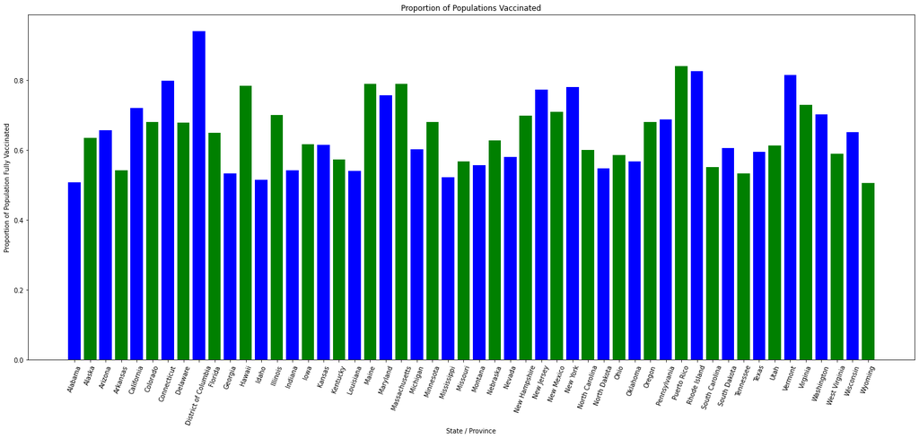

```python
date_getter = data.tail(1)
date = date_getter.iloc[0]['Date']
data2 = data[data['Date'] == date]
total_pop = sum(data2['2022_Population'])
colors = ['blue','green']

plt.figure(figsize=(25,10))
plt.xticks(rotation = 70)
plt.xlabel('State / Province')
plt.ylabel('Proportion of Population Fully Vaccinated')
plt.title("Proportion of Populations Vaccinated")
plt.bar(data2['Province_State'],data2['Proportion_Vaccinated'], color = colors)
```

In the above plot, we can see the individual population proportion that has been vaccinated for each state (including D.C. and Puerto Rico). The five states with the highest proportion of their population vaccinated are Washington D.C., Puerto Rico, Rhode Island, Vermont and Connecticut. Although these states have the highest proportion of their population vaccinated, it’s important to note that three of the states (and territories) mentioned above are among those with the smallest population. Vermont, D.C., and Rhode Island are within the 10 least populated states in the U.S. Collectively, they only account for a little under 3% of the entire U.S. population (9,145,122 people). Just looking at each state’s individual vaccinated proportion from a static perspective doesn’t give us the information that we are looking for. To take our analysis a step further, we will take a look at the distribution of each state’s daily vaccinations over a 16-month period.

### 6.2 Plotting State Vaccinations over Time

Next, we were interested in how the vaccination rates across the different states developed over time.

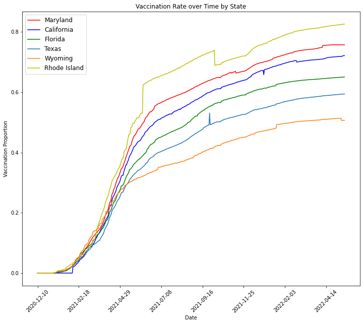

```python
plt.figure(figsize=(12,10))
plt.title('Vaccination Rate over Time by State')
plt.xlabel('Date')
plt.ylabel('Vaccination Proportion')
plt.ticklabel_format(style='plain')


# Plotting Maryland's Vaccination Data
data2 = data[data['Province_State']=='Maryland']
plt.plot(data2.Date, data2.Proportion_Vaccinated, color='r', label='Maryland')

# Plotting California's Vaccination Data
data2 = data[data['Province_State']=='California']
plt.plot(data2.Date, data2.Proportion_Vaccinated, color='b', label='California')

# Plotting Florida's Vaccination Data
data2 = data[data['Province_State']=='Florida']
plt.plot(data2.Date, data2.Proportion_Vaccinated, color='g', label='Florida')

# Plotting Texas's Vaccination Data
data2 = data[data['Province_State']=='Texas']
plt.plot(data2.Date, data2.Proportion_Vaccinated, label='Texas')

# Plotting Wyoming's Vaccination Data
data2 = data[data['Province_State']=='Wyoming']
plt.plot(data2.Date, data2.Proportion_Vaccinated, label='Wyoming')

# Plotting Rhode Island's Vaccination Data
data2 = data[data['Province_State']=='Rhode Island']
plt.plot(data2.Date, data2.Proportion_Vaccinated, color='y',label='Rhode Island')

plt.legend(loc='upper left',fontsize= 'large')

Dates = data['Date'].unique()
plt.xticks(Dates[::70],rotation=45)

plt.show()
```

Since 52 states and territories is a lot to plot on one graph, we chose a just a few to demonstrate the range of data that this dataset carries. We decided to plot the vaccination rate over time for six different states: Maryland, California, Texas, Florida, Wyoming, and Rhode Island. We chose to show Maryland’s vaccination rate because that’s our home state, and we thought it would be interesting to analyze how we have done in regards to vaccinations during the pandemic. We chose to plot California’s vaccination rate to see how the most populated state vaccinated it’s population over time, and we chose Wyoming to view the same for the least populated state. Texas and Florida are the second and third most populated states in the country, respectively, and Rhode Island is another state with a small population.

### 6.3 Plotting Total U.S. Vaccinations over Time

Now, as a country, we want to be able to be better prepared for another outbreak situation similar to what we experience the past few years with COVID-19. By using and manipulating our data, we can try and predict how effective we might be in vaccinating the majority of our citizens should another COVID-like outbreak occur.

```python
lst = []
for dates in data['Date'].unique():
  data2 = data[data['Date']==dates]
  lst.append([dates,sum(data2['People_Fully_Vaccinated'])])


sum_data = pd.DataFrame(lst, columns = ['Date','Total_Vaccinations'])
sum_data
```

|  | Date | Total_Vaccinations |
| --- | --- | --- |
| 0 | 2020-12-10 | 0.0 |
| 1 | 2020-12-11 | 0.0 |
| 2 | 2020-12-12 | 0.0 |
| 3 | 2020-12-13 | 0.0 |
| 4 | 2020-12-14 | 0.0 |
| ... | ... | ... |
| 517 | 2022-05-11 | 220067854.0 |
| 518 | 2022-05-12 | 220230142.0 |
| 519 | 2022-05-13 | 220261072.0 |
| 520 | 2022-05-14 | 220308887.0 |
| 521 | 2022-05-15 | 220335689.0 |

522 rows × 2 columns

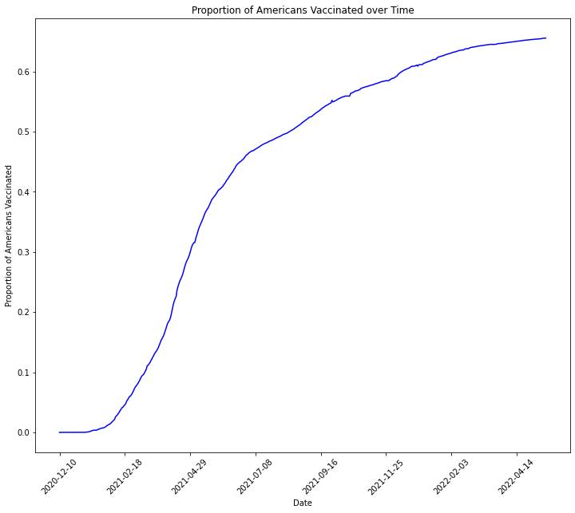

```python
# Plot Vaccinations over Time
plt.figure(figsize=(12,10))
plt.plot(sum_data.Date,sum_data.Total_Vaccinations/total_pop,color = 'b')

# Reorganizes The Plot
Dates = data['Date'].unique()
plt.xticks(Dates[::70],rotation=45)
plt.title('Proportion of Americans Vaccinated over Time')
plt.xlabel('Date')
plt.ylabel('Proportion of Americans Vaccinated')
```

Above, we have gathered the number of total U.S. citizens vaccinated at the end of each day, starting from December 10, 2020 and ending on May 14, 2022, and then we plotted the total proportion of Americans vaccinated over time, so that we can take a look at the total vaccination rate for the entire country. We can see that around late-January to early-February is when the vaccination rate for the country started to increase, and relatively sharply at that. It continues to increase at this rate for about 6-7 months, and then the vaccination rate starts to decrease gradually until May 14, 2022. The total proportion of Americans getting vaccinated is still increasing, however, it is increasing at an ever-slowing rate. To look at the relationship between the total proportion vaccinated over time to predict our efficiency to combat against another outbreak-like scenario, we need to plot the regression line for our data.

### 6.4 Plotting Regression onto Total Vaccinations Over Time

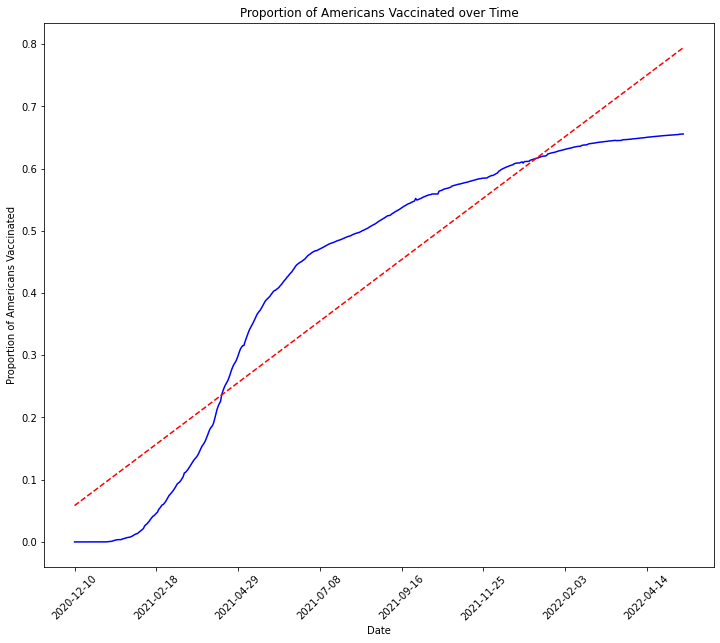

```python
plt.figure(figsize=(12,10))
sum_data['date_ordinal'] = sum_data['Date'].apply(lambda date: date.toordinal())
sum_data['Total_Proportion'] = sum_data['Total_Vaccinations'].apply(lambda total: total/total_pop)

#Creates Regression Function
plt.figure(figsize=(12,10))
x = sum_data['date_ordinal']
y = sum_data['Total_Proportion']
coef = np.polyfit(x,y,deg=1)
poly1d_fn = np.poly1d(coef)

#Plots Vaccination Proportion and Regression
plt.plot(sum_data.Date,sum_data.Total_Proportion,color = 'b')
plt.plot(x,poly1d_fn(x),'--r')

#Reorganized the plot
Dates = sum_data['Date'].unique()
plt.xticks(Dates[::70],rotation=45)
plt.ylabel('Proportion of Americans Vaccinated')
plt.xlabel('Date')
plt.title('Proportion of Americans Vaccinated over Time')
```

By plotting a linear regression, we get the plot above. However, our data distribution clearly doesn’t match the regression line calculated, so we have to use another regression model. We decided to use quadratic since it matched our data much better, and that plot is shown below.

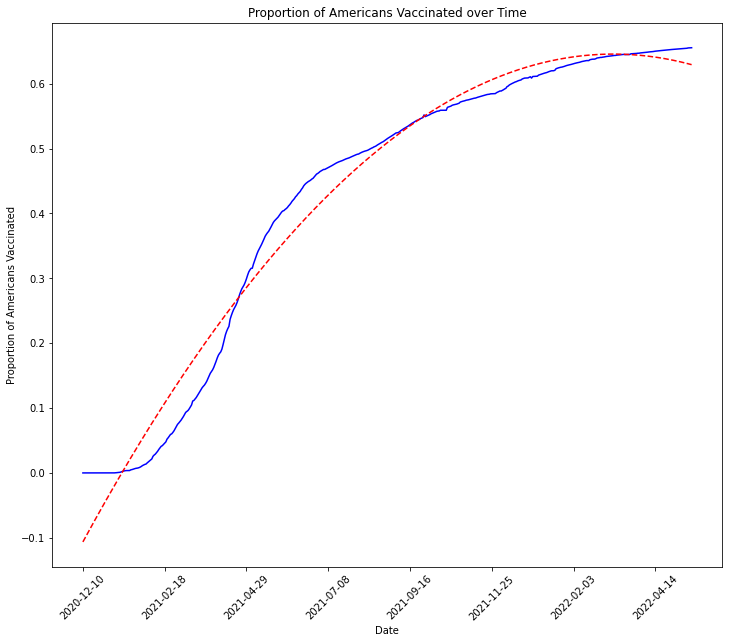

```python
# Creates Regression Function
plt.figure(figsize=(12,10))
x = sum_data['date_ordinal']
y = sum_data['Total_Proportion']
coef = np.polyfit(x,y,deg=2)
poly1d_fn = np.poly1d(coef)

# Plots Vaccination Proportion and Regression
plt.plot(sum_data.Date,sum_data.Total_Proportion,color = 'b')
plt.plot(x,poly1d_fn(x),'--r')

# Reorganized the plot
Dates = sum_data['Date'].unique()
plt.xticks(Dates[::70],rotation=45)
plt.ylabel('Proportion of Americans Vaccinated')
plt.xlabel('Date')
plt.title('Proportion of Americans Vaccinated over Time')
```

The above plot shows the proportion of Americans vaccinated over time from the start of the Covid-19 pandemic. This data can be analyzed and applied to approximately calculate how long it would take Americans to become vaccinated against a new strain or a new outbreak all together. According to the regression, 60 percent of Americans became vaccinated on approximately November 8th 2021.

The United States had its first confirmed case of Covid-19 on January 20th, 2020, meaning it took approximately 1 year and 10 months from the first confirmed case for 60 percent of U.S. citizens to become vaccinated against the virus. However, part of this time must be attributed to the development of the vaccine. Speaking of which, the FDA approved the first public vaccine on December 11th, 2020. This means the vaccine has been publicly available for close to 11 months. While many aspects of Covid-19 are unique and the development of a vaccine became the leading research in America, we can analyze the data to hypothesize that in the event of a new outbreak occurring it would take Americans, 11 months to reach 60 percent vaccination from the day the vaccine becomes available and 22 months from the first confirmed case in America.

## 7. Hypothesis Testing

### One-Sided Hypothesis Test

Now that we have sufficiently analyzed the data, we can use it to test certain hypotheses that we might have. According to [The Washington Post](https://www.washingtonpost.com/health/2022/03/22/funding-fourth-vaccine-doses/), about 65% of Americans are believed to be vaccinated by the Centers for Disease Control and Prevention. Lets test this claim against our data!

Let us define what our Null and Alternative Hypotheses will be. Our Null Hypothesis will be "The mean proportion of individuals vaccinated in the United States is 65%". Our Alternative Hypothesis will be "The mean proportion of individuals vaccinated in the United States is less than 65%".

As a note, we do not believe that the CDC is necessarily wrong, but our data was retrieved from Johns Hopkins. Perhaps there is a difference in the metrics both organizations use to qualify who a vaccinated individual is.

Since our data comes from the population of the United States as a whole, we will assume that it is normally distributed. The dependent variable is measured on an interval scale (time). Although the data isn't necessarily random (it comes from reports), we will be cautious about generalizing to a specific group of individuals. Lastly, there are clearly more than 30 samples inluded in the data. It should be safe for us to conduct a test!

```python
# Rettrieve proportion of vaccinated people from each state/territory
props = data2['Proportion_Vaccinated']

# Define alpha value (usually 0.05, or 5%)
alpha = 0.05

# Perform hypothesis test
# H0: proportion = 0.65
# H1: proportion < 0.65
tset, pval = ttest_1samp(props, popmean=0.65, alternative='less')

print("p-value: ", pval)

if pval < alpha:
   print("We are rejecting the null hypothesis.")
else:
  print("We are not rejecting the null hypothesis.")
```

```
p-value:  0.5508348324220964
We are not rejecting the null hypothesis.
```

As we can see, we got a pvalue of approximately 0.551. This is way larger than our alpha value, so we fail to reject the Null Hypothesis. Lets check what the mean proportion of vaccinated individuals is for our data.

```python
print("Mean Proportion Vaccinated Across States: ", np.mean(props))
```

```
Mean Proportion Vaccinated Across States:  0.6518376019832888
```

As we can clearly see, the data we retrieved from Johns Hopkins corroborates the statement given to us by the CDC. It should be noted that even the data we gathered may be inacurate to a certain extent; remember, we dropped some U.S. territories and government agencies from our DataFrame initially. This only means that the mean proportion vaccinated is most likely greater than ~65.2%.

### Two-Sample Hypothesis Test

Next, let us test to see whether there is a noticeable difference between the vacccination rates in large states and small states. We have to define what we mean by a "large" and "small" state. We are not talking about total land mass as much as we mean total population within the state. We shall define the cutoff as being 5,000,000 residents within the state. This should roughly seperate the states into equal groups.

```python
# Seperate data into two groups
small_states = data[data["2022_Population"] <= 5_000_000]
large_states = data[data["2022_Population"] > 5_000_000]

small_lst = small_states["Province_State"].unique()
large_lst = large_states["Province_State"].unique()

num_small = len(small_lst)
num_large = len(large_lst)

print("Small States: ", '\n', small_lst)
print("Number of Small States: ", num_small)
print("----------------------------------------------------------------")
print("Large States: ", '\n', large_lst)
print("Number of Large States: ", num_large)
```

```
Small States:
 ['Alabama' 'Alaska' 'Arkansas' 'Connecticut' 'Delaware'
 'District of Columbia' 'Hawaii' 'Idaho' 'Iowa' 'Kansas' 'Kentucky'
 'Louisiana' 'Maine' 'Mississippi' 'Montana' 'Nebraska' 'Nevada'
 'New Hampshire' 'New Mexico' 'North Dakota' 'Oklahoma' 'Oregon'
 'Puerto Rico' 'Rhode Island' 'South Dakota' 'Utah' 'Vermont'
 'West Virginia' 'Wyoming']
Number of Small States:  29
----------------------------------------------------------------
Large States:
 ['Arizona' 'California' 'Colorado' 'Florida' 'Georgia' 'Illinois'
 'Indiana' 'Maryland' 'Massachusetts' 'Michigan' 'Minnesota' 'Missouri'
 'New Jersey' 'New York' 'North Carolina' 'Ohio' 'Pennsylvania'
 'South Carolina' 'Tennessee' 'Texas' 'Virginia' 'Washington' 'Wisconsin']
Number of Large States:  23
```

Let us define our hypotheses. Our Null Hypothesis will be "There is no difference in the proportion of vacccinated individuals across small and large states". Our Alternative Hypothesis will be "There is a differene in the proportion of vaccinated individuals across small and large states".

```python
# Get current small states data
date_getter = small_states.tail(1)
date = date_getter.iloc[0]['Date']
small_states2 = small_states[small_states['Date'] == date]

# Get current large states data
date_getter = large_states.tail(1)
date = date_getter.iloc[0]['Date']
large_states2 = large_states[large_states['Date'] == date]
```

```python
small_states2
```

|  | Province_State | Date | People_Fully_Vaccinated | People_Partially_Vaccinated | 2022_Population | Proportion_Vaccinated |
| --- | --- | --- | --- | --- | --- | --- |
| 521 | Alabama | 2022-05-15 | 2511927.0 | 569271.0 | 4949697 | 0.507491 |
| 1043 | Alaska | 2022-05-15 | 457433.0 | 53386.0 | 720763 | 0.634651 |
| 2087 | Arkansas | 2022-05-15 | 1647265.0 | 376005.0 | 3042017 | 0.541504 |
| 3653 | Connecticut | 2022-05-15 | 2833460.0 | 585492.0 | 3546588 | 0.798926 |
| 4175 | Delaware | 2022-05-15 | 677221.0 | 136037.0 | 998619 | 0.678158 |
| 4697 | District of Columbia | 2022-05-15 | 676066.0 | 166621.0 | 718355 | 0.941131 |
| 6263 | Hawaii | 2022-05-15 | 1098534.0 | 101639.0 | 1401709 | 0.783710 |
| 6785 | Idaho | 2022-05-15 | 976732.0 | 127319.0 | 1896652 | 0.514977 |
| 8351 | Iowa | 2022-05-15 | 1958669.0 | 188475.0 | 3174426 | 0.617015 |
| 8873 | Kansas | 2022-05-15 | 1796871.0 | 379003.0 | 2919179 | 0.615540 |
| 9395 | Kentucky | 2022-05-15 | 2569418.0 | 391639.0 | 4487233 | 0.572606 |
| 9917 | Louisiana | 2022-05-15 | 2491382.0 | 349736.0 | 4616106 | 0.539715 |
| 10439 | Maine | 2022-05-15 | 1073199.0 | 147833.0 | 1359677 | 0.789304 |
| 13049 | Mississippi | 2022-05-15 | 1545688.0 | 231333.0 | 2961536 | 0.521921 |
| 14093 | Montana | 2022-05-15 | 608162.0 | 90484.0 | 1093117 | 0.556356 |
| 14615 | Nebraska | 2022-05-15 | 1232430.0 | 129546.0 | 1960790 | 0.628537 |
| 15137 | Nevada | 2022-05-15 | 1878669.0 | 445701.0 | 3238601 | 0.580087 |
| 15659 | New Hampshire | 2022-05-15 | 962069.0 | 242294.0 | 1378449 | 0.697936 |
| 16703 | New Mexico | 2022-05-15 | 1496258.0 | 349879.0 | 2109093 | 0.709432 |
| 18269 | North Dakota | 2022-05-15 | 424454.0 | 76322.0 | 774008 | 0.548385 |
| 19313 | Oklahoma | 2022-05-15 | 2273250.0 | 546918.0 | 4007179 | 0.567294 |
| 19835 | Oregon | 2022-05-15 | 2943744.0 | 348135.0 | 4325290 | 0.680589 |
| 20879 | Puerto Rico | 2022-05-15 | 2684888.0 | 380413.0 | 3194714 | 0.840416 |
| 21401 | Rhode Island | 2022-05-15 | 877744.0 | 170654.0 | 1062583 | 0.826047 |
| 22445 | South Dakota | 2022-05-15 | 546418.0 | 133406.0 | 902542 | 0.605421 |
| 24011 | Utah | 2022-05-15 | 2065275.0 | 250393.0 | 3363182 | 0.614084 |
| 24533 | Vermont | 2022-05-15 | 507902.0 | 77357.0 | 622882 | 0.815406 |
| 26099 | West Virginia | 2022-05-15 | 1034259.0 | 132946.0 | 1755715 | 0.589081 |
| 27143 | Wyoming | 2022-05-15 | 295136.0 | 41284.0 | 582233 | 0.506904 |

```python
large_states2
```

|  | Province_State | Date | People_Fully_Vaccinated | People_Partially_Vaccinated | 2022_Population | Proportion_Vaccinated |
| --- | --- | --- | --- | --- | --- | --- |
| 1565 | Arizona | 2022-05-15 | 5012731.0 | 837953.0 | 7640796 | 0.656048 |
| 2609 | California | 2022-05-15 | 28610997.0 | 3922414.0 | 39664128 | 0.721332 |
| 3131 | Colorado | 2022-05-15 | 4053917.0 | 526370.0 | 5961083 | 0.680064 |
| 5219 | Florida | 2022-05-15 | 14423843.0 | 2653392.0 | 22177997 | 0.650367 |
| 5741 | Georgia | 2022-05-15 | 5828447.0 | 1128998.0 | 10936299 | 0.532945 |
| 7307 | Illinois | 2022-05-15 | 8757727.0 | 971016.0 | 12518071 | 0.699607 |
| 7829 | Indiana | 2022-05-15 | 3712468.0 | 445663.0 | 6842385 | 0.542569 |
| 10961 | Maryland | 2022-05-15 | 4600541.0 | 655012.0 | 6075314 | 0.757252 |
| 11483 | Massachusetts | 2022-05-15 | 5463662.0 | 1332075.0 | 6922107 | 0.789306 |
| 12005 | Michigan | 2022-05-15 | 6022677.0 | 679111.0 | 9995212 | 0.602556 |
| 12527 | Minnesota | 2022-05-15 | 3909790.0 | 333238.0 | 5739781 | 0.681174 |
| 13571 | Missouri | 2022-05-15 | 3510611.0 | 620376.0 | 6184843 | 0.567615 |
| 16181 | New Jersey | 2022-05-15 | 6862642.0 | 1311929.0 | 8870685 | 0.773632 |
| 17225 | New York | 2022-05-15 | 15012171.0 | 2571432.0 | 19223191 | 0.780941 |
| 17747 | North Carolina | 2022-05-15 | 6500006.0 | 2418942.0 | 10807491 | 0.601435 |
| 18791 | Ohio | 2022-05-15 | 6878050.0 | 571495.0 | 11727377 | 0.586495 |
| 20357 | Pennsylvania | 2022-05-15 | 8798765.0 | 2103995.0 | 12805190 | 0.687125 |
| 21923 | South Carolina | 2022-05-15 | 2942190.0 | 547397.0 | 5342388 | 0.550726 |
| 22967 | Tennessee | 2022-05-15 | 3730537.0 | 523167.0 | 7001803 | 0.532797 |
| 23489 | Texas | 2022-05-15 | 17884432.0 | 3415994.0 | 30097526 | 0.594216 |
| 25055 | Virginia | 2022-05-15 | 6310245.0 | 1067049.0 | 8638218 | 0.730503 |
| 25577 | Washington | 2022-05-15 | 5538970.0 | 5716231.0 | 7887965 | 0.702205 |
| 26621 | Wisconsin | 2022-05-15 | 3825747.0 | 364589.0 | 5867518 | 0.652021 |

By doing this, we were able to get the current day information for the vaccination data in both small and large states.

```python
small_props = small_states2["Proportion_Vaccinated"]
large_props = large_states2["Proportion_Vaccinated"]

print(np.var(small_props) / np.var(large_props))
```

```
2.0737341729705485
```

As a rule of thumb, we can generally perform a two-sample test if the variances of the sample data sets are approximately equal. Above, the ratio between the small states and the large states is about 2:1, which is not necessarily equal. Many differnet publications and sources define what a good cutoff ratio is when dealing with different data sets, but for the purpose of this tutorial, we will assume that the variances are not equal. This is fine, since the 'ttest_ind()' function from scipy has a parameter that allows us to account for this!

```python
# Define alpha value (usually 0.05, or 5%)
alpha = 0.05

# Perform hypothesis test
# H0: prop_small - prop_large = 0 (there is no difference)
# H1: prop_small - prop_large =/= 0 (there is a differenec)
tset, pval = ttest_ind(small_props, large_props, equal_var=False)

print("p-value: ", pval)

if pval < alpha:
   print("We are rejecting the null hypothesis.")
else:
  print("We are not rejecting the null hypothesis.")
```

```
p-value:  0.822775892639231
We are not rejecting the null hypothesis.
```

As we can see, our pvalue was about 0.823, which is way larger than our alpha value. Thus, we do not reject the null hypothesis. Lets check what the mean proportion of vaccinated individuals is for our data.

```python
print("Mean Proportion Vaccinated Across Small States: ", np.mean(small_props))
print("Mean Proportion Vaccinated Across Large States: ", np.mean(large_props))
```

```
Mean Proportion Vaccinated Across Small States:  0.6490560096828262
Mean Proportion Vaccinated Across Large States:  0.6553448270577846
```

As we can see from the data itself, there does not appear to be a signifiant differnece between the mean proportion of vaccinated individuals across large and small states. There are many explanations for this.

First off, it could be the case that there is no significant difference in the vaccination rates across individuals in the U.S. when grouping by large and small state.

Another explanation could how we chose to define a "large" state versus a "small" state. We chose 5,000,000 as our value because this was a nice, even number that somewhat split our data into two groups of equal length. It should be noted that there are outliers in both sets of data, namely states such as Wyoming and Vermont with extremely small populations, and California and Texas with extremely large populations. A different cutoff point could lead us to different results.

## 8. Future Work

We can use this data to further explore how effective our country would be during another outbreak in regards to total vaccination, but areas such as vaccination accessibility, state and country immunity, and more. Pairing our data with data on why certain states have low vaccination rates can also help us determine how to combat these areas of low vaccinations, so that we can make sure we vaccinate the majority of our country as quick as possible should something like the COVID scenario happen again. Running regression models to determine the relationship between these factors, and running tests for statistical significance would allow us to prove (or disprove) any hypotheses surrounding this area, as well as predict hypothetical future trends for our country in regards to a spontaneous disease outbreak. While we provided a brief analysis on this data, there is definitely more analysis that can be done. In this tutorial, we focused more on the exploration of the data, and how to use basic data manipulation to reveal simple trends. However, we hope that this brief introduction to exploratory data analysis provides a good understanding as to how it can be useful when it comes to examining data. There are a lot of ways to take this analysis to the next level. To help you get started, here are some suggestions:

- Explore vaccine dosage and/or brand proportion
- Visualize vaccination trends across demographics such as age, race, gender, political identification, etc.
- More in-depth statistical analysis (tests for significance)
- Using vaccination data to predict state-level trends (related or unrelated)

We recommend that you familiarize yourself with the data sued in this tutorial, as well as the exploratory, data cleaning, and analysis techniques used before beginning further analysis.

## 9. References

### Data

- Johns Hopkins University Covid Data: https://github.com/govex/COVID-19
- State Population Data: https://worldpopulationreview.com/states

### Contact Info.

Thank you for making it to the end of our data exploration tutorial. Feel free to reach out with any clarifying questions, comments, or concerns.

- Christopher Tang: ctang127@umd.edu
- Jonathan Hayden: jhayden9@terpmail.umd.edu
- Alexander Ramirez: aramire8@umd.edu